# AI in Sustainability Communication: Implications for Research and Education

**Topic:** *The Adoption of AI in Strategic Communications;*  
**Subtopic:** *The Future Impact of AI in Strategic Communications and PR Education*

Authors

Nils Holmberg (nils.holmberg@iko.lu.se)

Jörgen Eksell (jorgen.eksell@iko.lu.se)

Published

July 11, 2025

## Abstract

Sustainability communication, a vital subset of strategic communication, leverages targeted messaging to shape audience attitudes and behaviors toward environmental and social responsibility. The rise of artificial intelligence (AI) is transforming this field, with analytical AI tools—such as natural language processing (NLP) and computer vision—offering robust methods for empirical analysis, while generative AI supports creative and pedagogical innovation. This chapter advocates for a balanced approach to AI adoption, integrating the empirical rigor of analytical AI with the creative potential of generative models to advance sustainability communication research and education.

### AI and Sustainability Communication Research

Analytical AI enhances the study of sustainability communication by enabling systematic, scalable analysis of multimodal content. For instance, NLP techniques like transformer-based models (e.g., BERT) and semantic similarity metrics analyze how corporations like Shell frame “energy” or “innovation” as business opportunities, while NGOs like WWF emphasize moral duty. Such tools also detect greenwashing by identifying discrepancies between claimed and actual sustainability practices through aspect-based sentiment analysis, which isolates evaluative language around themes like “carbon emissions” or “renewable energy.” Similarly, computer vision facilitates the analysis of visual sustainability messaging. Object detection identifies recurring symbols or environmental imagery, while facial expression analysis interprets audience reactions in campaign videos, enabling researchers to uncover manipulative or inconsistent messaging strategies.

### AI and Sustainability Communication Education

The integration of AI into sustainability communication necessitates a shift in educational approaches. Communication professionals must evolve from message creators to data-driven strategists, using analytical AI for evidence-based decision-making and stakeholder analysis. In education, generative AI serves as a pedagogical tool, enabling students to prototype communication campaigns, generate visualizations, or write data analysis code for sentiment or framing studies. For example, students can use AI to simulate sustainability messaging or automate content analysis, fostering skills in data interpretation and ethical AI use. Curricula must emphasize AI literacy, critical pedagogy, and open science principles like transparency and reproducibility to prepare students for a data-rich communicative landscape.

In conclusion, AI’s role in sustainability communication extends beyond automation to empower researchers and educators with tools for nuanced analysis and innovative teaching. By bridging computational methods with conceptual frameworks, this chapter equips communicators to navigate the evolving demands of sustainability communication with precision and accountability.

## First author bio: Nils Holmberg

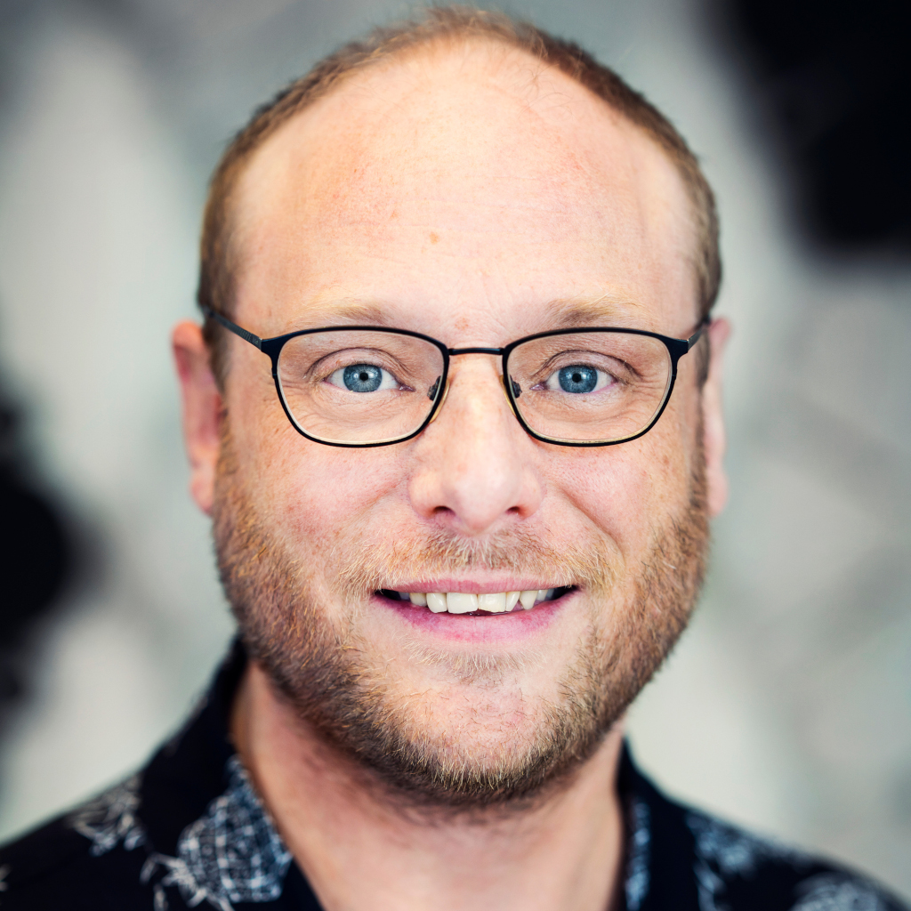

Nils Holmberg holds a PhD in Media and Communication Science from Lund University (2016). His dissertation investigated how web advertising affects children aged 9–12 when solving online tasks, using experimental methods and eye-tracking to assess visual attention and comprehension. The study contributed to understanding the complex digital marketing ecosystem and the use of physiological methods in communication research. His current research focuses on computational content analysis for the social sciences, applying quantitative methods to extract and visualize content features from digital texts and images. This work explores how techniques like natural language processing and computer vision can help analyze communication patterns related to societal issues. Institutional website: https://portal.research.lu.se/en/persons/nils-holmberg

## Second author bio: Jörgen Eksell

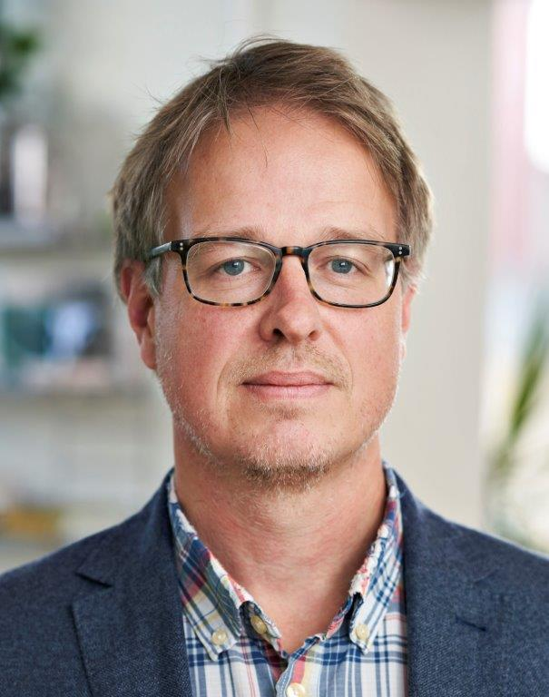

Jörgen Eksell holds a PhD in Service Studies from Lund University (2013) and is a senior lecturer in Strategic Communication. His work focuses on sustainable development, investigating the interplay between human activities, sustainability, and resilience. In research, he has collaborated with various stakeholders to enhance policymaking and practice. In recent years, he has also done research on the professionalisation of strategic communication education. He has specialised expertise in research areas such as place branding, resilience, sustainability, value proposition, and communication work. Through his research, he aims to contribute to a more sustainable future by addressing complex environmental challenges and promoting effective communication strategies. His insights are vital for fostering environmental stewardship and advancing sustainability initiatives. Institutional website: https://portal.research.lu.se/sv/persons/jörgen-eksell